# Part 4. Hierarchical clustering

Clustering genes by differential expression value allow to locate genes which were affected the most.  
Here we use the wrapper function ‘clusterGenes’ to produce a heatmap of significant DE genes.

```r
library(vic3PCD)
suppressMessages(library(pheatmap))
suppressMessages(library(kableExtra))
suppressMessages(library(DESeq2))
suppressMessages(library(RColorBrewer))
```

#### Annotation

Creating annotation object. Here we combine novel and existing annotations in a single data frame.

```r
# Load Novel transcripts annotation
annot_novel <- readRDS(system.file("extdata", "GenesTableFull_cp_NOVEL_annotation.rda", package = "vic3PCD"))

# Load default annotation and join it with novel data
annot <- readRDS(system.file("extdata", "GenesTableFull_cp_annotation.rda", package = "vic3PCD")) %>%
  dplyr::bind_rows(annot_novel) %>%
  tibble::remove_rownames()
# rownames(annot) <- annot$gene_id
```

#### Data

Creading DESeq2 data object using SE object

```r
# Load SE dataset
se <- readRDS(system.file("extdata", "se_vic3_2020.RData", package = "vic3PCD"))

# DESeq dataset
dds <- DESeqDataSet(se, design = ~ condition)

# To make sure we have right category used as reference in the analysis
dds$condition <- relevel(dds$condition, ref = "Control")

# DESeq analysis
dds <- DESeq(dds, test = "Wald", sfType = "poscounts", useT = FALSE, minReplicatesForReplace = 7)

# Filter genes with more than 10 aligned reads
keep <- rowSums(counts(dds)) >= 10
dds <- dds[keep,]
```

## Hierarchical Clustering

To perform clustering with ‘clusterGenes’ first we define a significance threshold.  
Genes will be filtered based on significance p-value produced by DESeq2 and DE value.

To identify the number of clusters use the tree on the left. Imagine a vertical line going through the tree. Place it so that it crosses horizontal lines on the tree without crossing any vertical line. Count how many horizontal lines it crosses. That will give an approximate number of clusters.

The heatamp the right most column contains sample means for each gene (row means).

```r
# Threshold values
val = 1.9
pval = 0.001
clastTree = 6

groups <- clusterGenes(dds = dds,
                        annotationTbl = annot,
                        summarise_clusters = FALSE,
                        value = val,
                        pvalue = pval,
                        cutTree = clastTree,
                        distRows = "euclidean",
                        clusterMethod = "average")
```

```
#> Selecting genes...
#> Minimum value is -4.24692433050571
#> Maximum value is 12.8630063814232
#> done
#> Creating pheatmap...
#> done
```

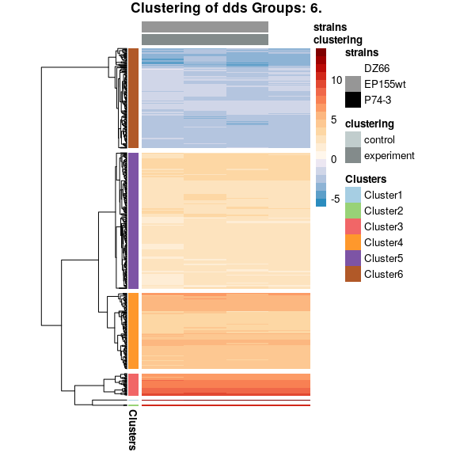

Here is a partial view on clustering table.

```r
tbl <- dplyr::arrange(groups,desc(log2FoldChange))

tbl <- tbl[c(1:10), c("gene_id", "proteinId", "X6_3_EP155mix", "X6_4_EP155mix", "X6_5_EP155mix", "Mean", "baseMean", "log2FoldChange", "pvalue")]

kable(tbl, escape = F, linesep = "", booktabs = T, longtable = F, caption = "Hierarchical Clustering (partial)") %>%
  kable_styling(latex_options = c("scale_down", "repeat_header"), bootstrap_options = c("condensed"), font_size = 12, full_width = F) %>%
    column_spec(1, bold = T)
```

Hierarchical Clustering (partial)

| gene_id | proteinId | X6_3_EP155mix | X6_4_EP155mix | X6_5_EP155mix | Mean | baseMean | log2FoldChange | pvalue |
| --- | --- | --- | --- | --- | --- | --- | --- | --- |
| gene2138 | 85578 | 12.972736 | 13.128890 | 13.146641 | 13.082755 | 145511.42761 | 12.9 | 0 |
| gene10363 | 266940 | 10.605379 | 10.804436 | 10.734749 | 10.714855 | 2821.53644 | 10.7 | 0 |
| CPNOV.6992 | NA | 10.408176 | 10.530943 | 10.562006 | 10.500375 | 66552.16309 | 10.4 | 0 |
| gene1041 | 248648 | 8.835949 | 9.165788 | 9.167983 | 9.056573 | 200.39608 | 9.9 | 0 |
| gene10428 | 333311 | 9.446703 | 9.449233 | 9.415684 | 9.437207 | 442.17199 | 9.8 | 0 |
| gene6445 | 227067 | 9.289822 | 9.681626 | 9.398414 | 9.456620 | 578.52757 | 9.8 | 0 |
| CPNOV.8539 | NA | 8.028546 | 7.763218 | 7.637144 | 7.809636 | 53.72785 | 9.8 | 0 |
| gene1233 | 220168 | 9.321663 | 9.448837 | 9.422000 | 9.397500 | 913.31868 | 9.5 | 0 |
| gene2824 | 250362 | 8.892658 | 9.152350 | 8.943254 | 8.996087 | 251.21897 | 9.5 | 0 |
| gene5278 | 328954 | 8.531077 | 8.497179 | 8.420631 | 8.482962 | 116.94344 | 9.4 | 0 |

Another useful option for ‘clusterGenes’ function is to make a heatmap of average DE values in each cluster for in individual samples. This is a summarised version of Hierarchical clustering plot. In addition to row means column it also creates a variance column for each cluster.

```r
groups <- clusterGenes(dds = dds,
                        annotationTbl = annot,
                        summarise_clusters = TRUE,
                        value = val,
                        pvalue = pval,
                        cutTree = clastTree,
                        distRows = "euclidean",
                        clusterMethod = "average")
```

```
#> Selecting genes...
#> Minimum value is -4.24692433050571
#> Maximum value is 12.8630063814232
#> done
#> Creating pheatmap...
#> done
```

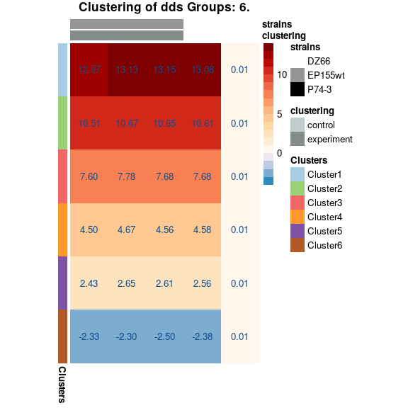